# Exploratory Data Analysis -EDA

2024-04-03

## Overview

Exploratory Data Analysis (EDA) is an essential process in understanding the characteristics of the data and uncovering insights that can guide further analysis and modeling. In the context of paint properties, EDA allows us to explore the relationships between color attributes (R, G, B values, Lightness, Saturation, Hue) and the response variable (popularity of the paint)

## Load Packages

The tidyverse is loaded in for you in the code chunk below. The visualization package, ggplot2, and the data manipulation package, dplyr, are part of the “larger” tidyverse.

```r
library(tidyverse)
```

The modelr package is loaded in for you in the code chunk below. You may use functions from modelr to calculate performance metrics for your models.

```r
library(modelr)
```

The caret package to manage all aspects of data splitting, training, and evaluating the models.

```r
library(caret)
```

## Import Data

Importing data is a foundational step in data analysis and predictive modeling tasks. In R, the `readr` package offers a straightforward method for reading CSV files into data frames. For this task, we aim to import both training and holdout datasets stored in CSV format. The approach involves defining file paths for the datasets and using the `read_csv` function to read the files into data frames. We set `col_names = TRUE` to automatically detect column names from the first row of each CSV file. The training data is stored in a data frame named `df_train`, while the holdout data is stored in `df_holdout`. By executing this code, the datasets are ready for further analysis, feature engineering, and modeling tasks.

```r
# Importing training data
train_data_path <- 'paint_project_train_data.csv'
df_train <- readr::read_csv(train_data_path, col_names = TRUE)
df_train %>% glimpse()
```

```
## Rows: 835
## Columns: 8
## $ R          <dbl> 172, 26, 172, 28, 170, 175, 90, 194, 171, 122, 0, 88, 144, …
## $ G          <dbl> 58, 88, 94, 87, 66, 89, 78, 106, 68, 151, 121, 140, 82, 163…
## $ B          <dbl> 62, 151, 58, 152, 58, 65, 136, 53, 107, 59, 88, 58, 132, 50…
## $ Lightness  <chr> "dark", "dark", "dark", "dark", "dark", "dark", "dark", "da…
## $ Saturation <chr> "bright", "bright", "bright", "bright", "bright", "bright",…
## $ Hue        <dbl> 4, 31, 8, 32, 5, 6, 34, 10, 1, 21, 24, 22, 36, 16, 26, 12, …
## $ response   <dbl> 12, 10, 16, 10, 11, 16, 10, 19, 14, 25, 14, 19, 14, 38, 15,…
## $ outcome    <dbl> 1, 1, 1, 0, 0, 0, 0, 0, 0, 0, 0, 0, 0, 0, 0, 0, 0, 0, 1, 1,…
```

## Visualize the Distributions of Variables

**Counts for Categorical Variables**

**Lightness Distribution**

The Bar plot visualizes the distribution of the Lightness variable in the training data. We first identify the unique categories (levels) present in the Lightness variable and define a color palette with seven distinct colors. We then map each unique category to a color from the palette, ensuring that each category is represented by a unique color in the plot. Finally, we create the plot using ggplot() and display it with the specified color mapping, providing a clear and informative visualization of the distribution of Lightness in the training dataset.

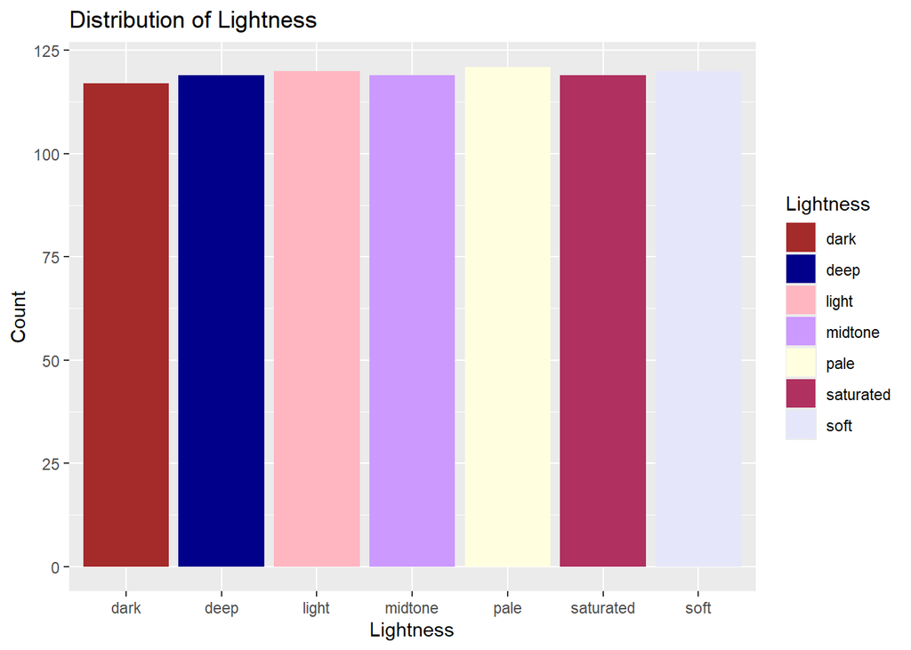

```r
# Get unique categories in Lightness
unique_lightness <- unique(df_train$Lightness)

# Define colors for each unique category
color_palette <- c("brown", "darkblue", "lightpink", "#CC99FF", "lightyellow", "maroon", "lavender")

# Create a named vector with colors for each unique category
color_values <- setNames(color_palette[1:length(unique_lightness)], unique_lightness)

plot_lightness <- ggplot(df_train, aes(x = Lightness, fill = Lightness)) +
  geom_bar() +
  labs(title = "Distribution of Lightness",
       x = "Lightness", y = "Count") +
  scale_fill_manual(values = color_values)

plot_lightness
```

**Saturation Distribution**

The Bar plot visualizes the distribution of the Saturation variable in the training data. It begins by identifying the unique categories (levels) present in the Saturation variable and defines a color palette with seven distinct colors. Each unique category is then mapped to a color from the palette, ensuring that every category is represented by a unique color in the plot. The plot is created using ggplot() with Saturation on the x-axis and the count of each category on the y-axis. The plot is displayed with the specified color mapping, offering a clear and informative visualization of the distribution of Saturation in the training dataset.

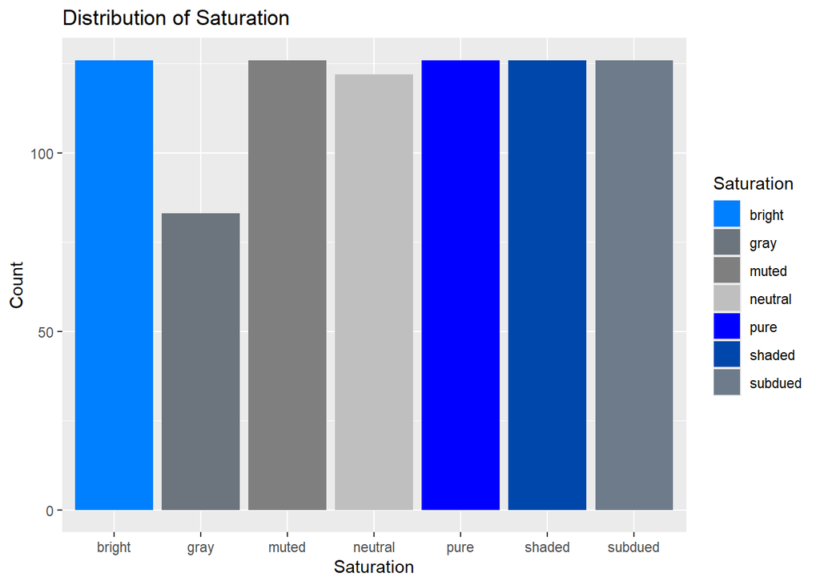

```r
# Get unique categories in Saturation
unique_saturation <- unique(df_train$Saturation)

# Define colors for each unique category
color_palette_saturation <- c(bright = "#007FFF",gray = "#6C757D",muted = "#7F7F7F",neutral = "#BFBFBF",pure = "#0000FF",shaded = "#0047AB",subdued = "#6E7B8B")

# Create a named vector with colors for each unique category
color_values_saturation <- setNames(color_palette_saturation[1:length(unique_saturation)], unique_saturation)

plot_saturation <- ggplot(df_train, aes(x = Saturation, fill = Saturation)) +
  geom_bar() +
  labs(title = "Distribution of Saturation",
       x = "Saturation", y = "Count") +
  scale_fill_manual(values = color_values_saturation)

plot_saturation
```

**Outcome Distribution**

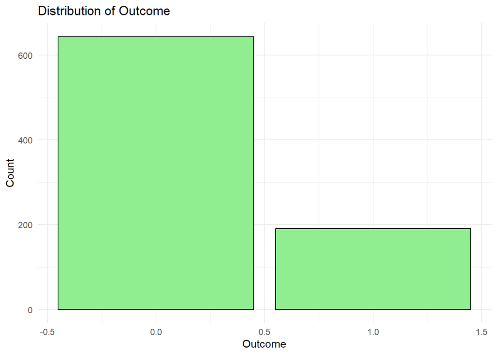

```r
plot_outcome <- ggplot(df_train, aes(x = outcome)) +
  geom_bar(color = "black", fill = "lightgreen") +
  labs(title = "Distribution of Outcome",
       x = "Outcome", y = "Count") +
  theme_minimal()
plot_outcome
```

**Continuous variables**

**Hue Distribution**

The histogram displays the distribution of the Hue variable in the training data. It sets the histogram bars to be filled with a uniform color and customizes the appearance of the plot, including the title and axis labels.

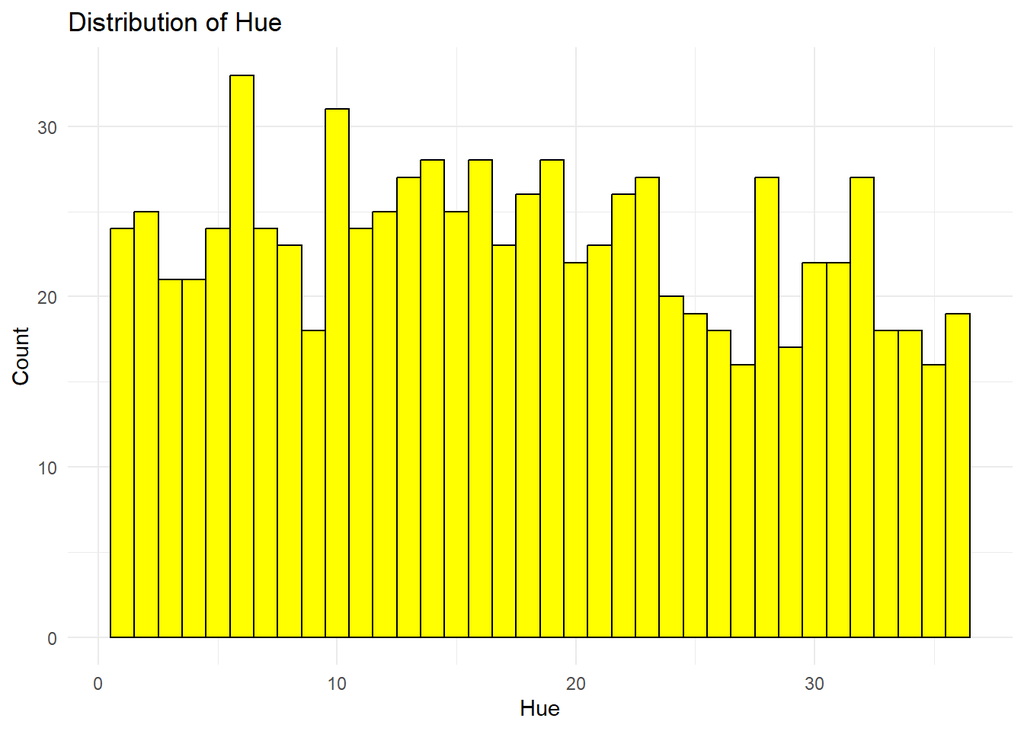

```r
plot_hue <- ggplot(df_train, aes(x = Hue)) +
  geom_histogram(color = "black", binwidth = 1, fill = "yellow",bins= 100) +
  labs(title = "Distribution of Hue",
       x = "Hue", y = "Count") +
  theme_minimal()
plot_hue
```

This distribution does not appear to be Gaussian or normally distributed. It seems to be more uniform, with counts fairly even across the range of Hue values, although there are some variations with certain values having slightly higher or lower counts. In a Gaussian distribution, we would expect to see a bell-shaped curve with most of the data clustering around the mean and symmetric tails on either side. This histogram does not show that pattern.

**Response Distribution**

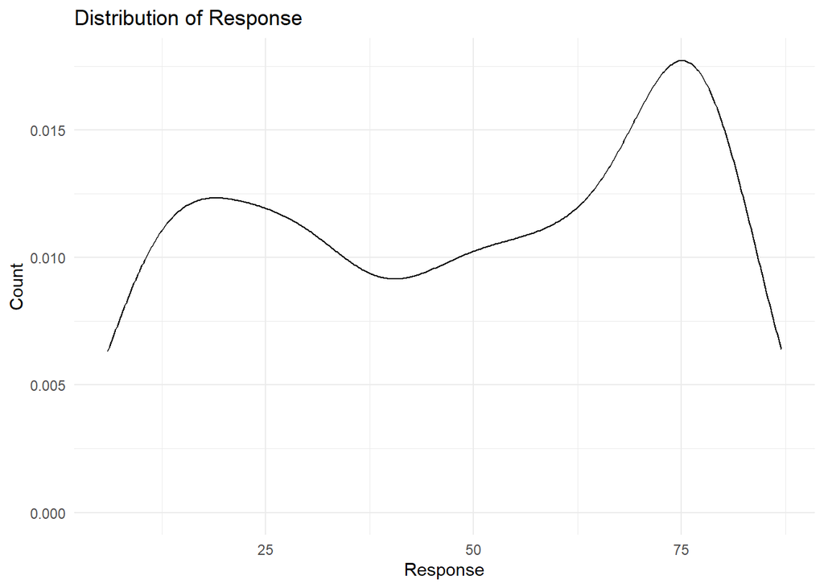

```r
plot_response <- ggplot(df_train, aes(x = response)) +
  geom_density(color = "black") +
  labs(title = "Distribution of Response",
       x = "Response", y = "Count") +
  theme_minimal()
plot_response
```

The density plot provided for the variable ‘Response’ shows a distribution with two peaks, which suggests a bimodal distribution. This is not characteristic of a Gaussian or normal distribution, which typically has a single, central peak (unimodal) and is symmetric. The presence of two peaks here indicates two modes of data, which could imply the existence of two underlying groups or processes within your ‘Response’ variable.

**RGB Distribution**

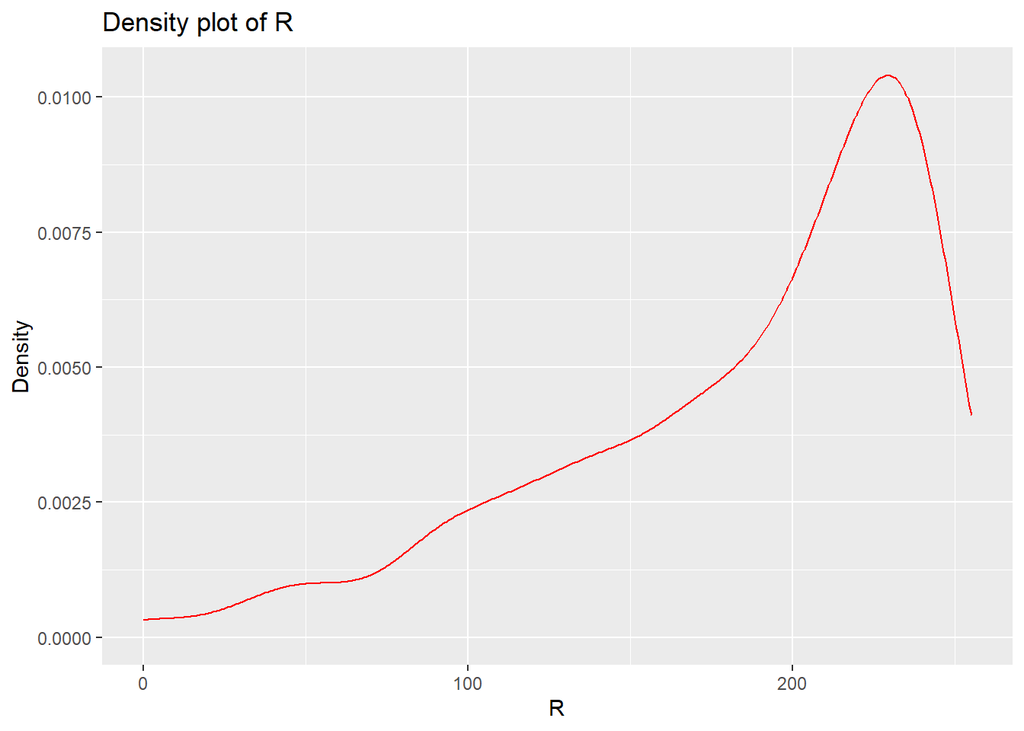

```r
ggplot(df_train, aes(x = R)) +
  geom_density(color = "red", alpha = 1) +
  ggtitle("Density plot of R") +
  xlab("R") +
  ylab("Density")
```

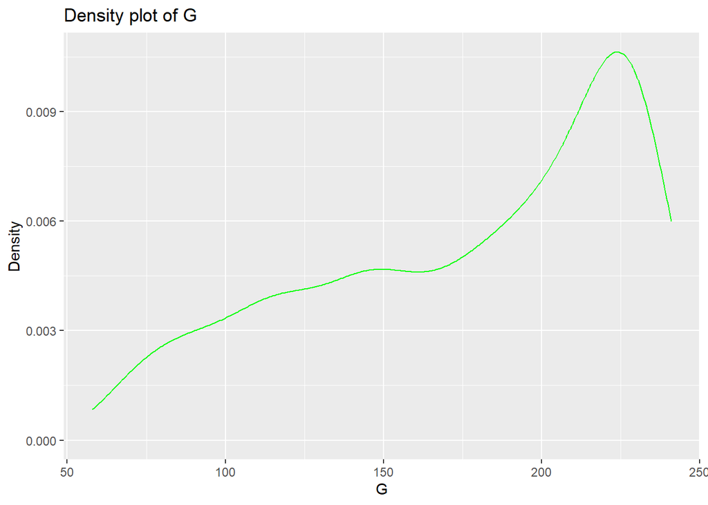

```r
ggplot(df_train, aes(x = G)) +
  geom_density(color = "green", alpha = 1) +
  ggtitle("Density plot of G") +
  xlab("G") +
  ylab("Density")
```

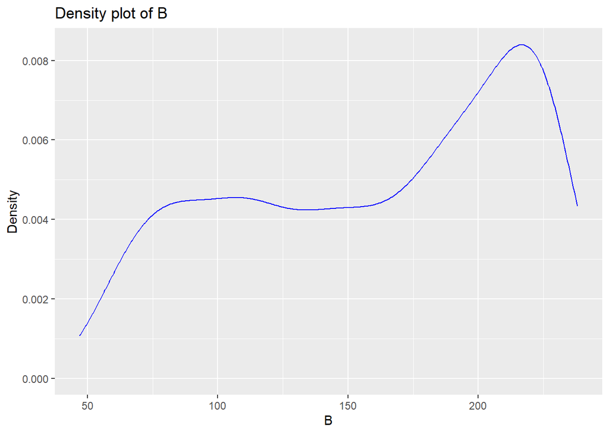

```r
ggplot(df_train, aes(x = B)) +
  geom_density(color = "blue", alpha = 1) +
  ggtitle("Density plot of B") +
  xlab("B") +
  ylab("Density")
```

These distributions is not typical of a Gaussian or normal distribution, which would have a symmetric bell-shaped curve. Instead, these density plot suggests the distributions are skewed, which is a common occurrence in real-world data.

## Group Continuous Variables Based on Categorical Variables

This analysis includes summarizing the dataset to understand the distribution and central tendencies of color components and response variables. Boxplots are utilized to visualize the relationships between color components and outcomes, both overall and within specific categories. T-tests are performed to assess the significance of differences in color components between outcome groups, providing insights into potential associations between color properties and outcomes.

The df_train_summary table provides summary statistics (mean, standard deviation, and median) for the variables R, G, B, and Hue grouped by Lightness and Saturation.

```r
df_train_summary <- df_train %>%
  group_by(Lightness, Saturation,outcome) %>%
  summarise(across(c(R, G, B, Hue,response), list(mean = mean, sd = sd, median = median)), .groups = 'drop')
df_train_summary
```

```
## # A tibble: 89 × 18
##    Lightness Saturation outcome R_mean  R_sd R_median G_mean  G_sd G_median
##    <chr>     <chr>        <dbl>  <dbl> <dbl>    <dbl>  <dbl> <dbl>    <dbl>
##  1 dark      bright           0  129.  71.8     155    112.  32.4     121
##  2 dark      bright           1  123.  84.3     172     80   19.3      88
##  3 dark      gray             0   95    4.24     94     90.8  7.37     90.5
##  4 dark      gray             1   92.2  6.18     93.5   84.7  7.66     84
##  5 dark      muted            0  121.  57.7     140.   108.  27.6     106.
##  6 dark      muted            1   98.5 62.7      99.5   69.2  7.09     68
##  7 dark      neutral          0   87.6 21.0      85.5   87.2 14.5      87.5
##  8 dark      neutral          1   83.4 35.2      99     80.8  9.91     81
##  9 dark      pure             0  153.  95.9     188    161.  41.1     155
## 10 dark      pure             1  183.  71.5     198    123.  53.6     111
## # ℹ 79 more rows
## # ℹ 9 more variables: B_mean <dbl>, B_sd <dbl>, B_median <dbl>, Hue_mean <dbl>,
## #   Hue_sd <dbl>, Hue_median <dbl>, response_mean <dbl>, response_sd <dbl>,
## #   response_median <dbl>
```

```r
anova_R <- aov(R_mean ~ Lightness + Saturation+ outcome, data = df_train_summary)
summary(anova_R)
```

```
##             Df Sum Sq Mean Sq F value  Pr(>F)
## Lightness    6 188540   31423  71.048 < 2e-16 ***
## Saturation   6   8777    1463   3.308 0.00608 **
## outcome      1   4964    4964  11.223 0.00127 **
## Residuals   75  33171     442
## ---
## Signif. codes:  0 '***' 0.001 '**' 0.01 '*' 0.05 '.' 0.1 ' ' 1
```

```r
anova_G <- aov(G_mean ~ Lightness + Saturation+ outcome, data = df_train_summary)
summary(anova_G)
```

```
##             Df Sum Sq Mean Sq F value   Pr(>F)
## Lightness    6 207838   34640 299.036  < 2e-16 ***
## Saturation   6  10450    1742  15.036 3.25e-11 ***
## outcome      1    267     267   2.305    0.133
## Residuals   75   8688     116
## ---
## Signif. codes:  0 '***' 0.001 '**' 0.01 '*' 0.05 '.' 0.1 ' ' 1
```

```r
anova_B <- aov(B_mean ~ Lightness + Saturation + outcome, data = df_train_summary)
summary(anova_B)
```

```
##             Df Sum Sq Mean Sq F value   Pr(>F)
## Lightness    6 218047   36341 286.343  < 2e-16 ***
## Saturation   6   4653     775   6.110 3.01e-05 ***
## outcome      1    919     919   7.238   0.0088 **
## Residuals   75   9519     127
## ---
## Signif. codes:  0 '***' 0.001 '**' 0.01 '*' 0.05 '.' 0.1 ' ' 1
```

```r
anova_Hue <- aov(Hue_mean ~ Lightness + Saturation+ outcome, data = df_train_summary)
summary(anova_Hue)
```

```
##             Df Sum Sq Mean Sq F value Pr(>F)
## Lightness    6   82.9   13.81   0.702 0.6489
## Saturation   6  282.8   47.14   2.396 0.0358 *
## outcome      1  111.4  111.43   5.663 0.0199 *
## Residuals   75 1475.7   19.68
## ---
## Signif. codes:  0 '***' 0.001 '**' 0.01 '*' 0.05 '.' 0.1 ' ' 1
```

```r
anova_Response <- aov(Hue_mean ~ Lightness + Saturation+ outcome, data = df_train_summary)
summary(anova_Response)
```

```
##             Df Sum Sq Mean Sq F value Pr(>F)
## Lightness    6   82.9   13.81   0.702 0.6489
## Saturation   6  282.8   47.14   2.396 0.0358 *
## outcome      1  111.4  111.43   5.663 0.0199 *
## Residuals   75 1475.7   19.68
## ---
## Signif. codes:  0 '***' 0.001 '**' 0.01 '*' 0.05 '.' 0.1 ' ' 1
```

These boxplots are created for the variables R, G, B and Hue by Lightness and Saturation. These boxplots visualize the distribution of each color component (R, G, B, Hue) across different levels of Lightness and Saturation.

**R distribution**

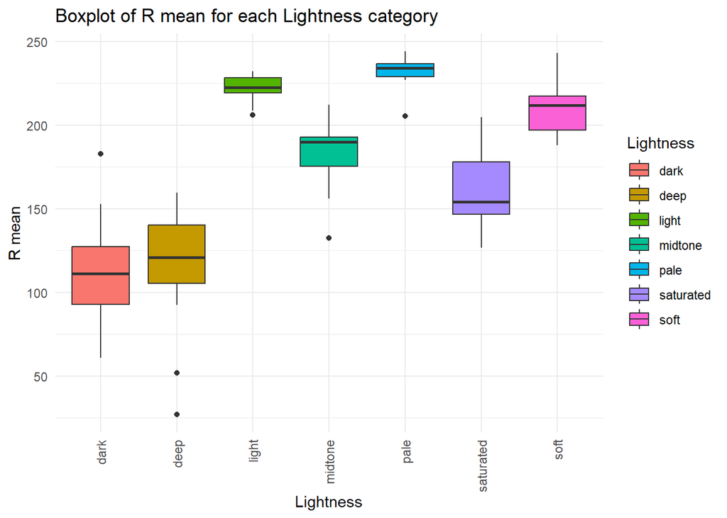

```r
ggplot(df_train_summary, aes(x = Lightness, y = R_mean, fill = Lightness)) +
  geom_boxplot() +
  theme_minimal() +
  labs(title = "Boxplot of R mean for each Lightness category", y = "R mean") +
  theme(axis.text.x = element_text(angle = 90, vjust = 0.5, hjust=1))
```

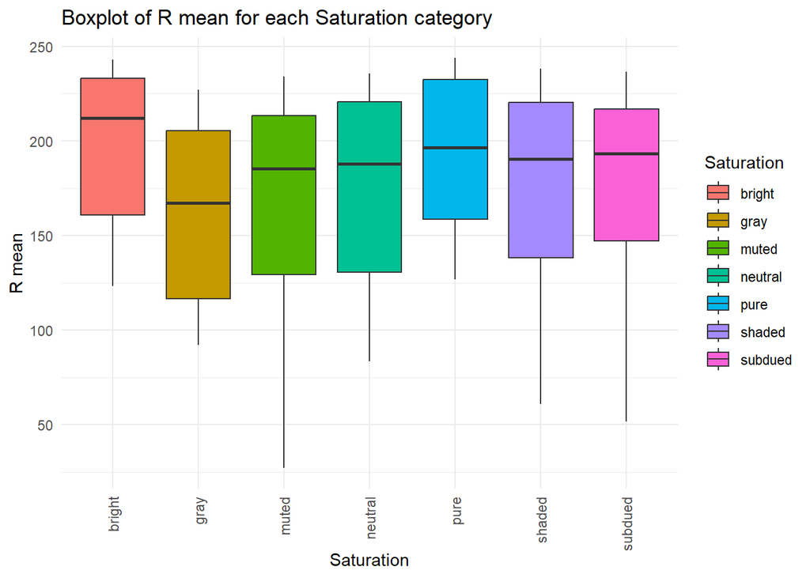

```r
ggplot(df_train_summary, aes(x = Saturation, y = R_mean, fill = Saturation)) +
  geom_boxplot() +
  theme_minimal() +
  labs(title = "Boxplot of R mean for each Saturation category", y = "R mean") +
  theme(axis.text.x = element_text(angle = 90, vjust = 0.5, hjust=1))
```

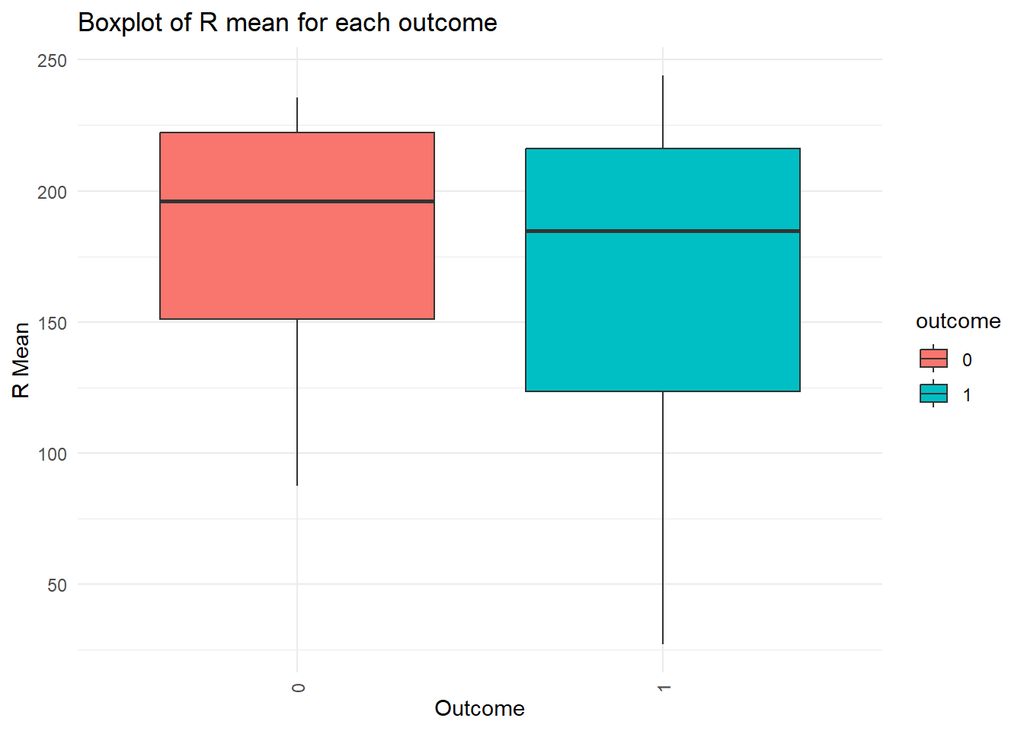

```r
df_train_summary$outcome <- factor(df_train_summary$outcome)

ggplot(df_train_summary, aes(x = outcome, y = R_mean, fill = outcome)) +
  geom_boxplot() +
  theme_minimal() +
  labs(title = "Boxplot of R mean for each outcome", x = "Outcome", y = "R Mean") +
  theme(axis.text.x = element_text(angle = 90, vjust = 0.5, hjust=1))
```

**G distribution**

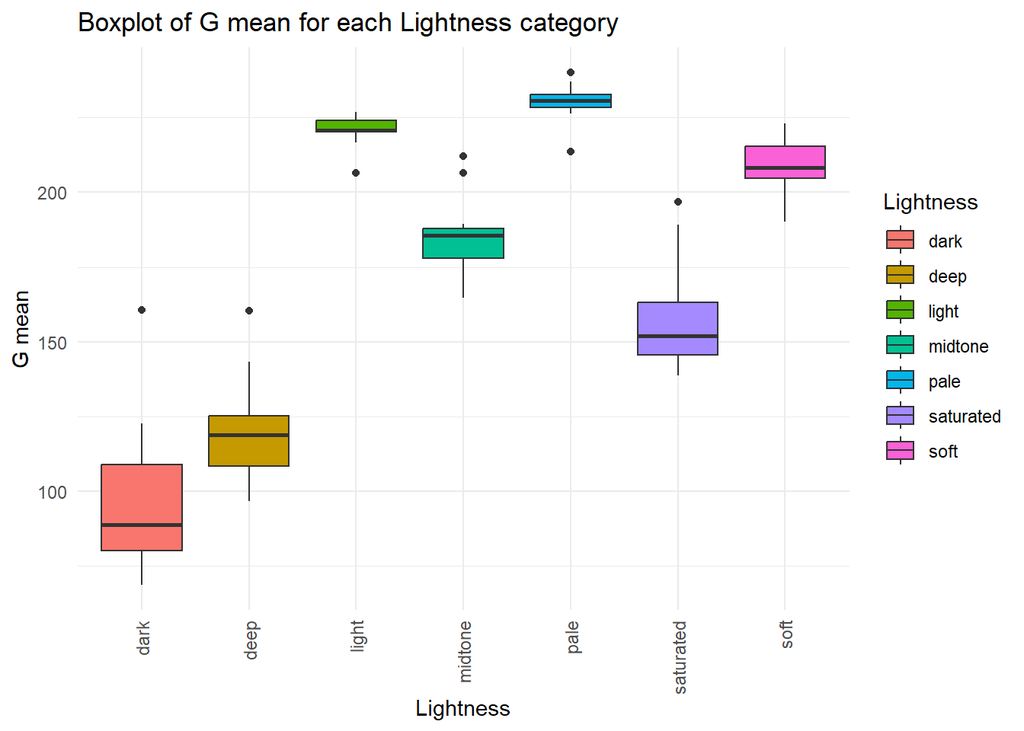

```r
ggplot(df_train_summary, aes(x = Lightness, y = G_mean, fill = Lightness)) +
  geom_boxplot() +
  theme_minimal() +
  labs(title = "Boxplot of G mean for each Lightness category", y = "G mean") +
  theme(axis.text.x = element_text(angle = 90, vjust = 0.5, hjust=1))
```

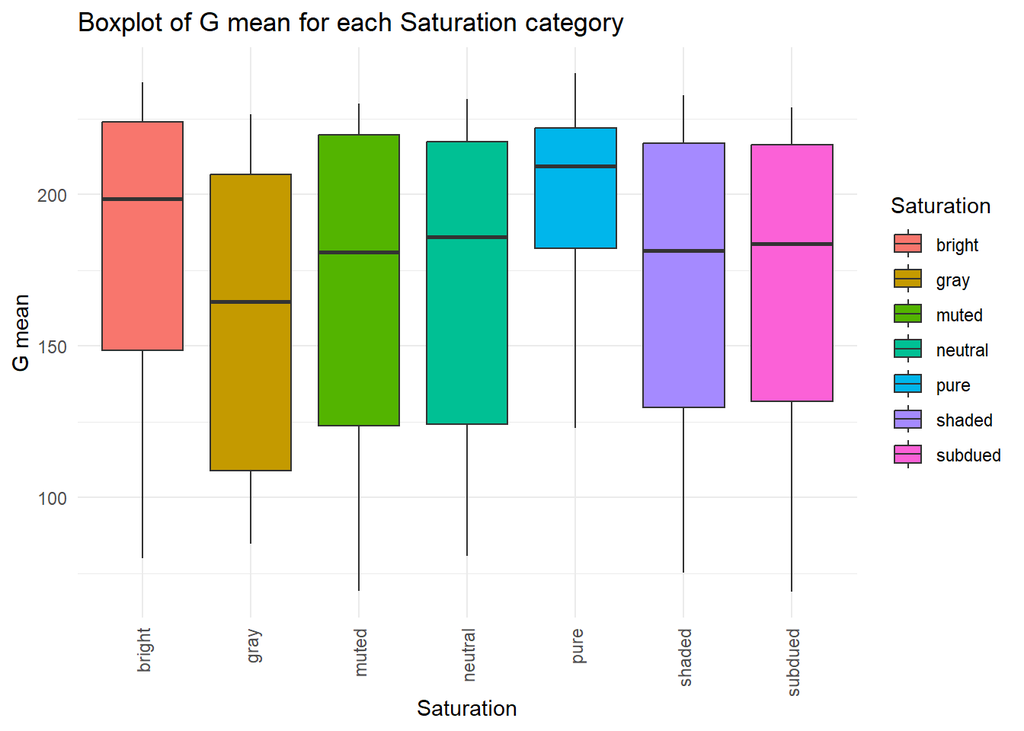

```r
ggplot(df_train_summary, aes(x = Saturation, y = G_mean, fill = Saturation)) +
  geom_boxplot() +
  theme_minimal() +
  labs(title = "Boxplot of G mean for each Saturation category", y = "G mean") +
  theme(axis.text.x = element_text(angle = 90, vjust = 0.5, hjust=1))
```

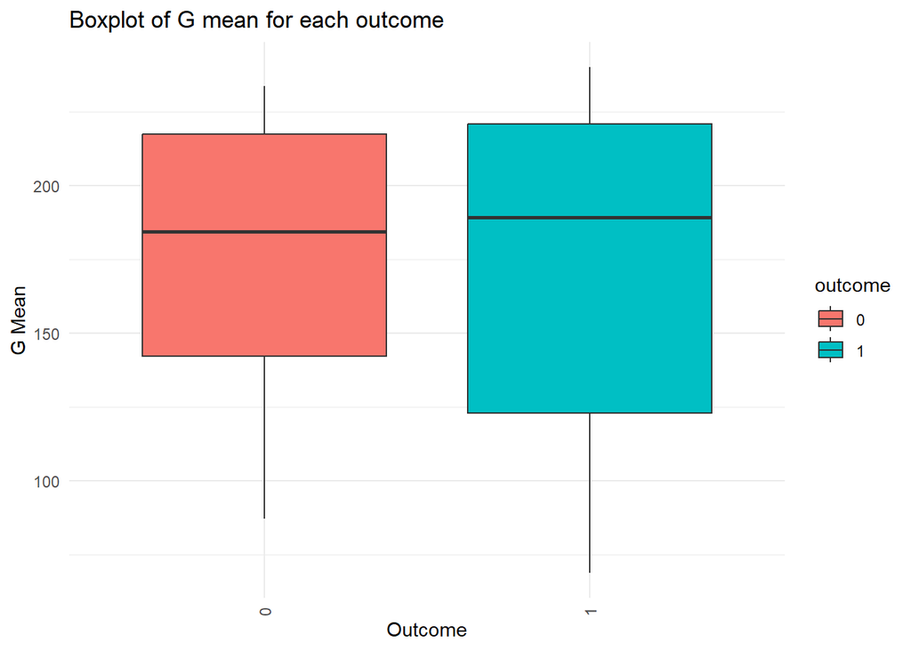

```r
df_train_summary$outcome <- factor(df_train_summary$outcome)

ggplot(df_train_summary, aes(x = outcome, y = G_mean, fill = outcome)) +
  geom_boxplot() +
  theme_minimal() +
  labs(title = "Boxplot of G mean for each outcome", x = "Outcome", y = "G Mean") +
  theme(axis.text.x = element_text(angle = 90, vjust = 0.5, hjust=1))
```

**B distribution**

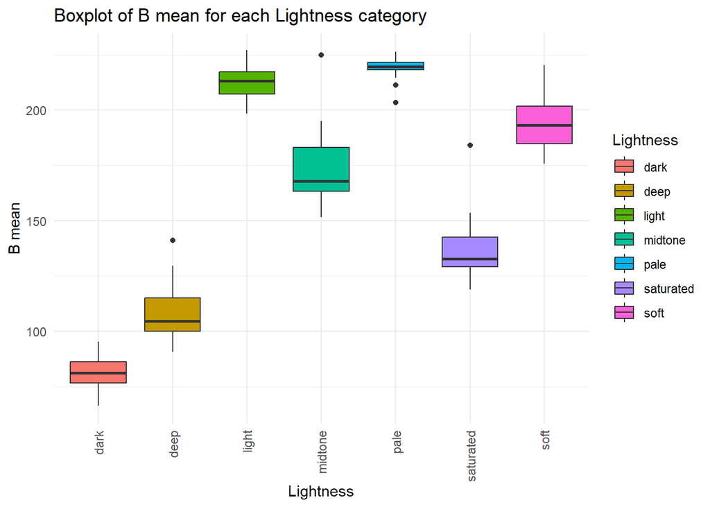

```r
ggplot(df_train_summary, aes(x = Lightness, y = B_mean, fill = Lightness)) +
  geom_boxplot() +
  theme_minimal() +
  labs(title = "Boxplot of B mean for each Lightness category", y = "B mean") +
  theme(axis.text.x = element_text(angle = 90, vjust = 0.5, hjust=1))
```

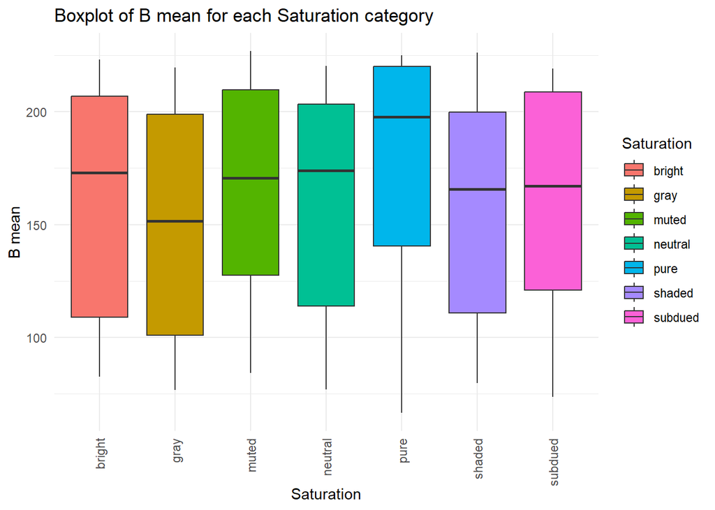

```r
ggplot(df_train_summary, aes(x = Saturation, y = B_mean, fill = Saturation)) +
  geom_boxplot() +
  theme_minimal() +
  labs(title = "Boxplot of B mean for each Saturation category", y = "B mean") +
  theme(axis.text.x = element_text(angle = 90, vjust = 0.5, hjust=1))
```

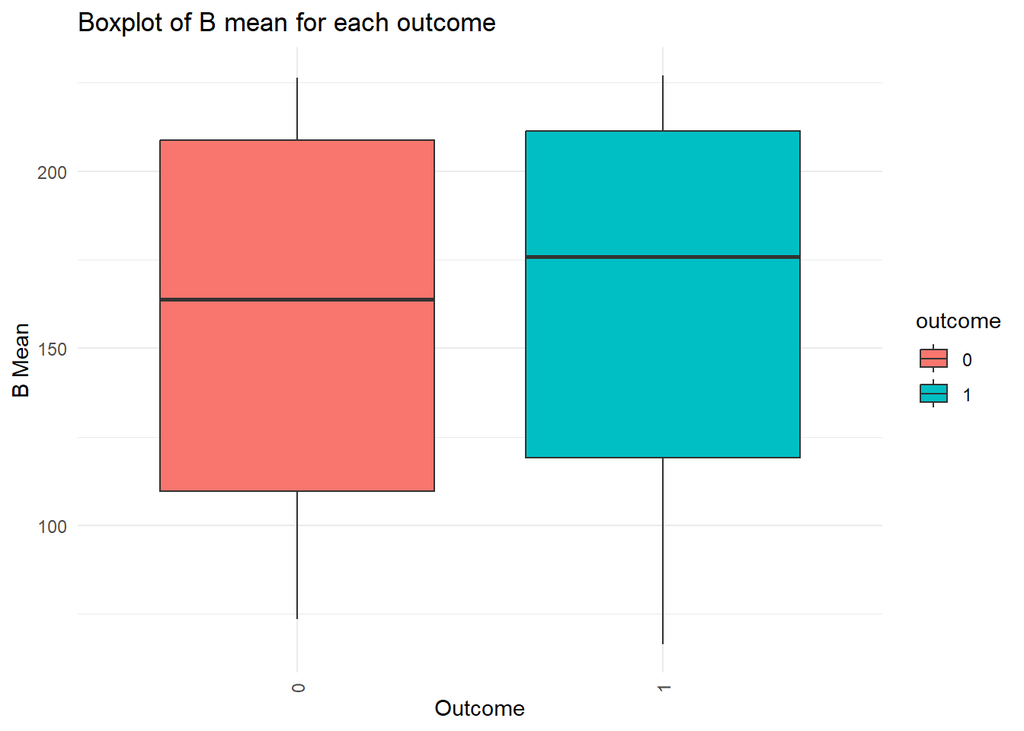

```r
df_train_summary$outcome <- factor(df_train_summary$outcome)

ggplot(df_train_summary, aes(x = outcome, y = B_mean, fill = outcome)) +
  geom_boxplot() +
  theme_minimal() +
  labs(title = "Boxplot of B mean for each outcome", x = "Outcome", y = "B Mean") +
  theme(axis.text.x = element_text(angle = 90, vjust = 0.5, hjust=1))
```

**Hue distribution**

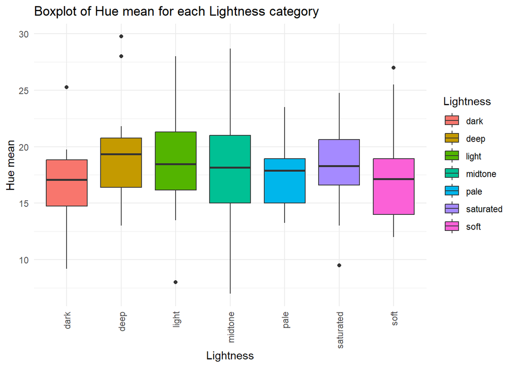

```r
ggplot(df_train_summary, aes(x = Lightness, y = Hue_mean, fill = Lightness)) +
  geom_boxplot() +
  theme_minimal() +
  labs(title = "Boxplot of Hue mean for each Lightness category", y = "Hue mean") +
  theme(axis.text.x = element_text(angle = 90, vjust = 0.5, hjust=1))
```

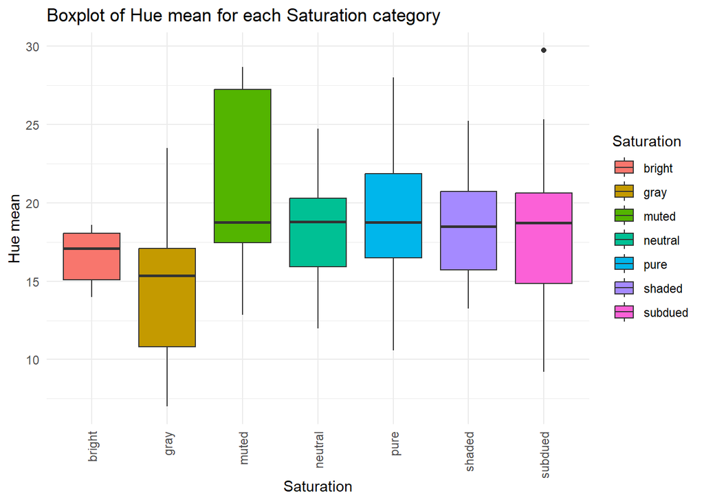

```r
ggplot(df_train_summary, aes(x = Saturation, y = Hue_mean, fill = Saturation)) +
  geom_boxplot() +
  theme_minimal() +
  labs(title = "Boxplot of Hue mean for each Saturation category", y = "Hue mean") +
  theme(axis.text.x = element_text(angle = 90, vjust = 0.5, hjust=1))
```

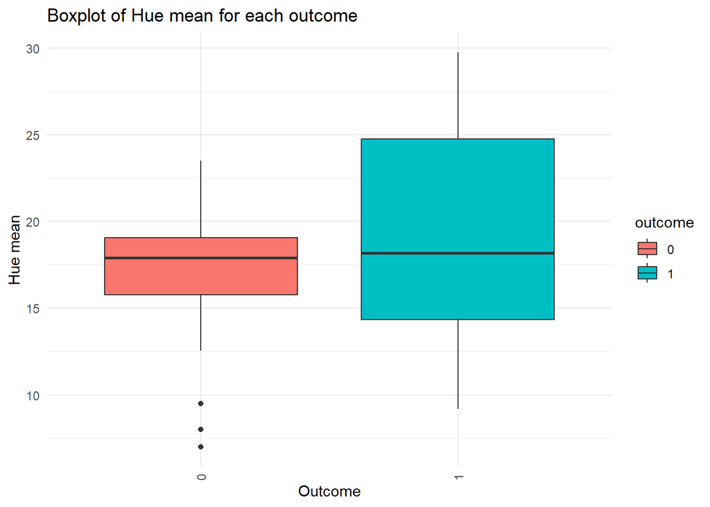

```r
df_train_summary$outcome <- factor(df_train_summary$outcome)

ggplot(df_train_summary, aes(x = outcome, y = Hue_mean, fill = outcome)) +
  geom_boxplot() +
  theme_minimal() +
  labs(title = "Boxplot of Hue mean for each outcome", x = "Outcome", y = "Hue mean") +
  theme(axis.text.x = element_text(angle = 90, vjust = 0.5, hjust=1))
```

**Response distribution**

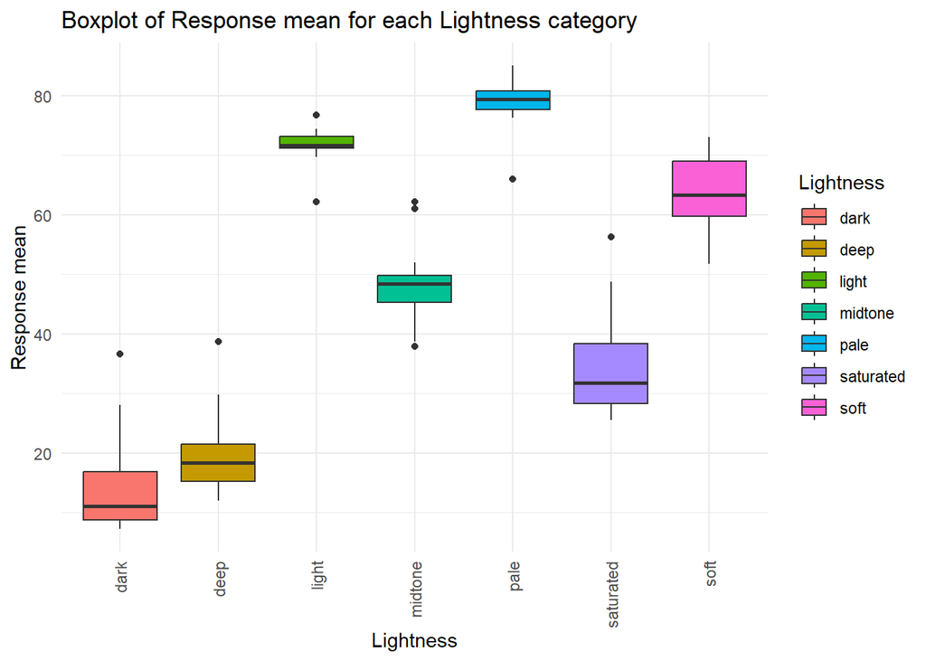

```r
ggplot(df_train_summary, aes(x = Lightness, y = response_mean, fill = Lightness)) +
  geom_boxplot() +
  theme_minimal() +
  labs(title = "Boxplot of Response mean for each Lightness category", y = "Response mean") +
  theme(axis.text.x = element_text(angle = 90, vjust = 0.5, hjust=1))
```

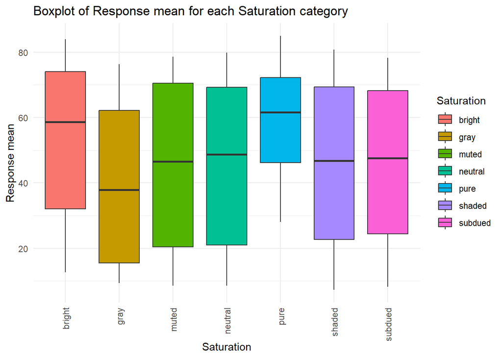

```r
ggplot(df_train_summary, aes(x = Saturation, y = response_mean, fill = Saturation)) +
  geom_boxplot() +
  theme_minimal() +
  labs(title = "Boxplot of Response mean for each Saturation category", y = "Response mean") +
  theme(axis.text.x = element_text(angle = 90, vjust = 0.5, hjust=1))
```

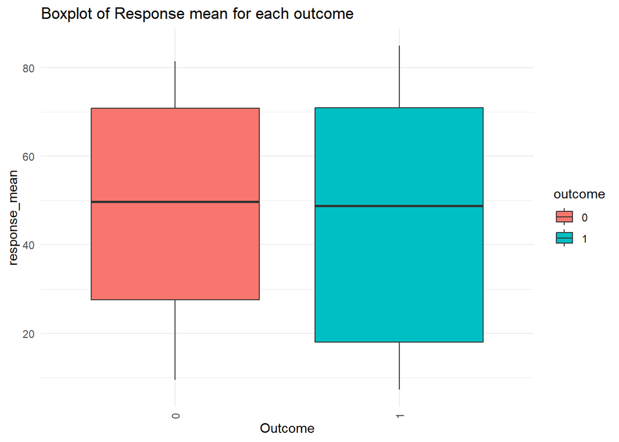

```r
df_train_summary$outcome <- factor(df_train_summary$outcome)

ggplot(df_train_summary, aes(x = outcome, y = response_mean, fill = outcome)) +
  geom_boxplot() +
  theme_minimal() +
  labs(title = "Boxplot of Response mean for each outcome", x = "Outcome", y = "response_mean") +
  theme(axis.text.x = element_text(angle = 90, vjust = 0.5, hjust=1))
```

```r
t_test_R <- t.test(R ~ outcome, data = df_train)
print(t_test_R)
```

```
##
##  Welch Two Sample t-test
##
## data:  R by outcome
## t = 3.5702, df = 294.49, p-value = 0.0004164
## alternative hypothesis: true difference in means between group 0 and group 1 is not equal to 0
## 95 percent confidence interval:
##   7.808789 26.993087
## sample estimates:
## mean in group 0 mean in group 1
##        187.3276        169.9267
```

```r
t_test_G <- t.test(G ~ outcome, data = df_train)
print(t_test_G)
```

```
##
##  Welch Two Sample t-test
##
## data:  G by outcome
## t = 2.2274, df = 279.02, p-value = 0.02672
## alternative hypothesis: true difference in means between group 0 and group 1 is not equal to 0
## 95 percent confidence interval:
##   1.154316 18.708388
## sample estimates:
## mean in group 0 mean in group 1
##        178.5963        168.6649
```

```r
t_test_B <- t.test(B ~ outcome, data = df_train)
print(t_test_B)
```

```
##
##  Welch Two Sample t-test
##
## data:  B by outcome
## t = -0.2589, df = 323.59, p-value = 0.7959
## alternative hypothesis: true difference in means between group 0 and group 1 is not equal to 0
## 95 percent confidence interval:
##  -9.780320  7.505483
## sample estimates:
## mean in group 0 mean in group 1
##        160.0668        161.2042
```

```r
t_test_Hue <- t.test(Hue ~ outcome, data = df_train)
print(t_test_Hue)
```

```
##
##  Welch Two Sample t-test
##
## data:  Hue by outcome
## t = -0.48609, df = 326.72, p-value = 0.6272
## alternative hypothesis: true difference in means between group 0 and group 1 is not equal to 0
## 95 percent confidence interval:
##  -1.978980  1.194778
## sample estimates:
## mean in group 0 mean in group 1
##        17.58696        17.97906
```

```r
t_test_Response <- t.test(response ~ outcome, data = df_train)
print(t_test_Response)
```

```
##
##  Welch Two Sample t-test
##
## data:  response by outcome
## t = 2.0913, df = 293.1, p-value = 0.03736
## alternative hypothesis: true difference in means between group 0 and group 1 is not equal to 0
## 95 percent confidence interval:
##  0.2584769 8.5152539
## sample estimates:
## mean in group 0 mean in group 1
##        49.60714        45.22028
```

The Welch Two Sample t-tests for ‘R’, ‘G’, and ‘response’ indicate significant differences in their mean values between the two binary outcome groups (p-values: 0.0004164, 0.02672, and 0.03736, respectively), suggesting that the distributions and summary statistics of these variables are influenced by the binary outcome. However, for ‘B’ and ‘Hue’, the p-values (0.7959 and 0.6272, respectively) do not indicate significant differences in mean values between the groups, implying that the binary outcome does not have the same level of impact on the distributions of these variables.

## Visualize the Relationships Between the Continuous Inputs

```r
cor_matrix <- cor(df_train[, c("R", "G", "B", "Hue","response")])
cor_matrix
```

```
##                   R         G         B         Hue    response
## R         1.0000000 0.7536893 0.5337811 -0.35907605  0.81677576
## G         0.7536893 1.0000000 0.8131972  0.05555940  0.97576872
## B         0.5337811 0.8131972 1.0000000  0.21223987  0.83556811
## Hue      -0.3590761 0.0555594 0.2122399  1.00000000 -0.00992191
## response  0.8167758 0.9757687 0.8355681 -0.00992191  1.00000000
```

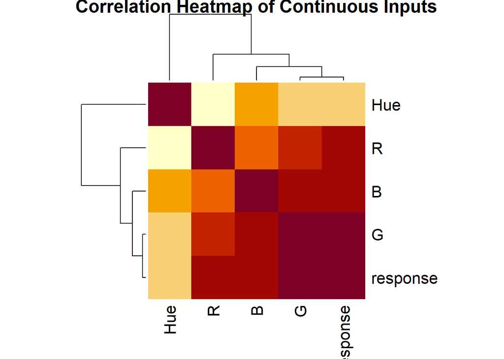

```r
heatmap(cor_matrix, symm = TRUE, main = "Correlation Heatmap of Continuous Inputs")
```

## Visualize the relationships between the continuous outputs (response and the LOGIT-transformed response, y) with respect to the continuous INPUTS.

**R vs Response and Logit-Transform**

```r
logit <- function(p) {
  log(p / (1 - p))
}

df_train$logit_response <- logit((df_train$response - 0) / (100 - 0))
```

**R vs Response and Logit-Transform**

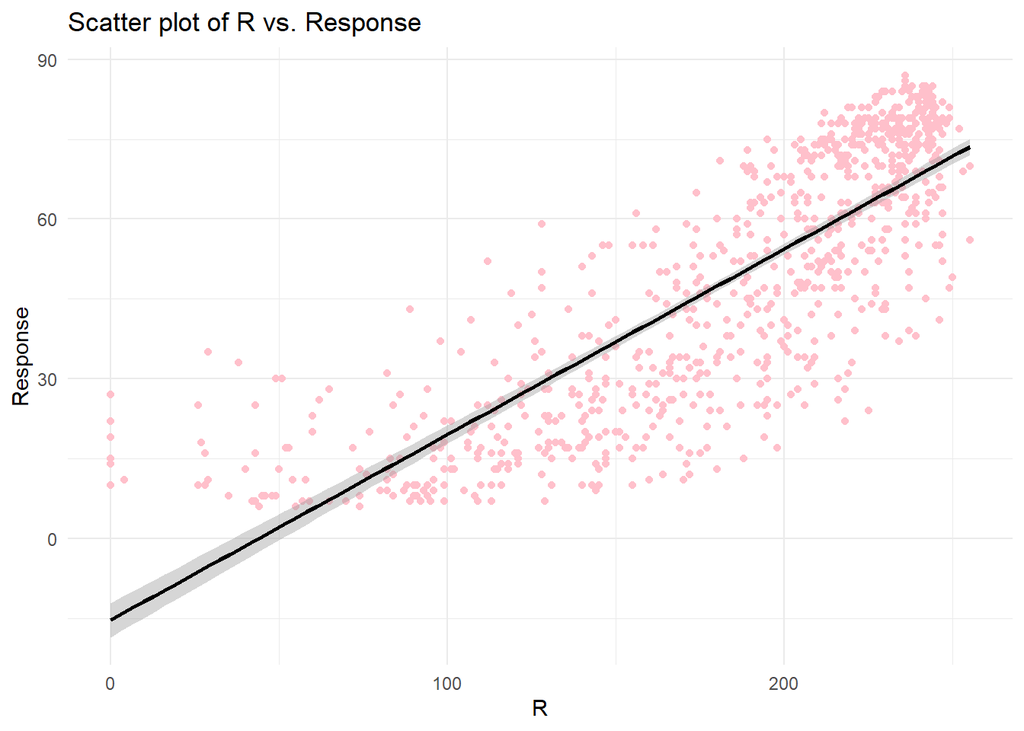

```r
ggplot(df_train, aes(x = R, y = response)) +
  geom_point(color="pink") +
  geom_smooth(method = "lm",formula = y ~ x, col = "black") +
  labs(title = "Scatter plot of R vs. Response", x = "R", y = "Response") +
  theme_minimal()
```

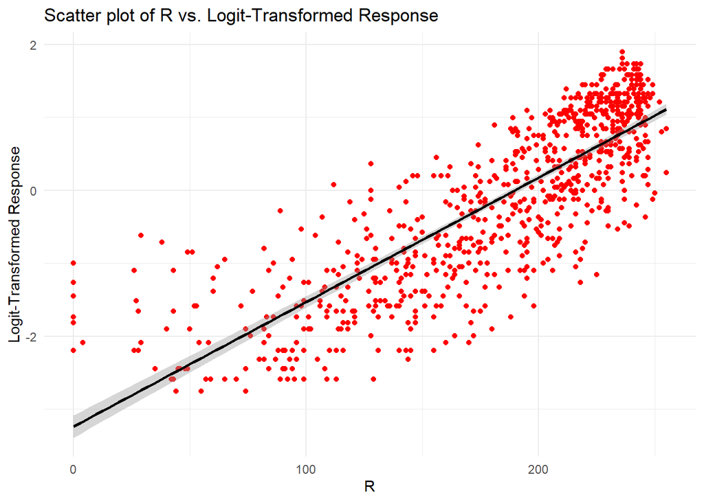

```r
ggplot(df_train, aes(x = R, y = logit_response)) +
  geom_point(color="red") +
  geom_smooth(method = "lm",formula = y ~ x, col = "black") +
  labs(title = "Scatter plot of R vs. Logit-Transformed Response", x = "R", y = "Logit-Transformed Response") +
  theme_minimal()
```

Both scatter plots of ‘R’ versus ‘Response’ and ‘R’ versus ‘Logit-Transformed Response’ show a strong positive linear relationship, indicating that higher values of ‘R’ are associated with higher responses, both before and after the logit transformation. The trend is clear and consistent in these visuals, but without differentiation by categorical inputs, it’s not possible to determine from these plots alone if the trend varies by categories like ‘Lightness’ or ‘Saturation’. For that, a further breakdown by categorical input values would be necessary.

**B vs Response and Logit-Transform**

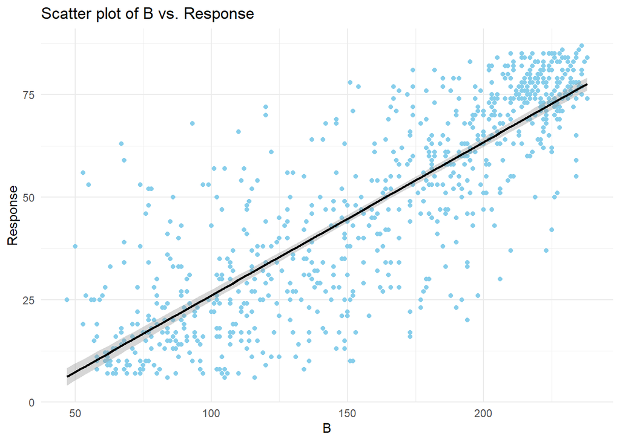

```r
ggplot(df_train, aes(x = B, y = response)) +
  geom_point(color="skyblue") +
  geom_smooth(method = "lm",formula = y ~ x, col = "black") +
  labs(title = "Scatter plot of B vs. Response", x = "B", y = "Response") +
  theme_minimal()
```

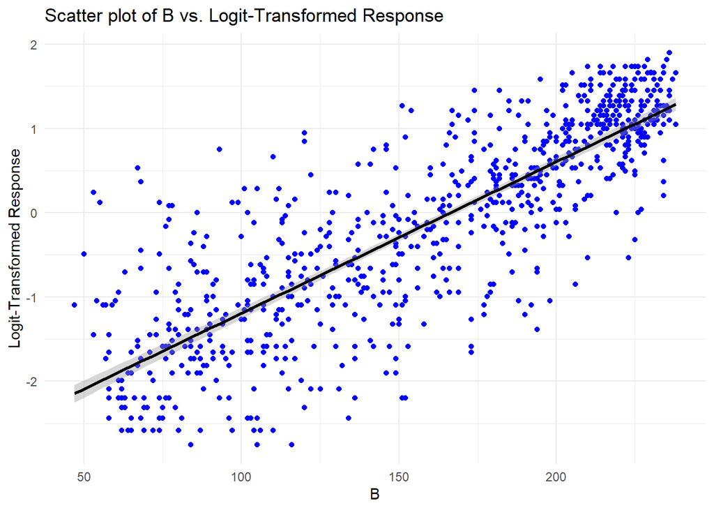

```r
ggplot(df_train, aes(x = B, y = logit_response)) +
  geom_point(color="blue") +
  geom_smooth(method = "lm",formula = y ~ x, col = "black") +
  labs(title = "Scatter plot of B vs. Logit-Transformed Response", x = "B", y = "Logit-Transformed Response") +
  theme_minimal()
```

The scatter plots for ‘B’ versus ‘Response’ and ‘B’ versus ‘Logit-Transformed Response’ both display a positive linear trend, indicating that as ‘B’ increases, so does both the response and its logit transformation. This relationship appears consistent and does not visibly depend on the categorical inputs within these plots.

**G vs Response and Logit-Transform**

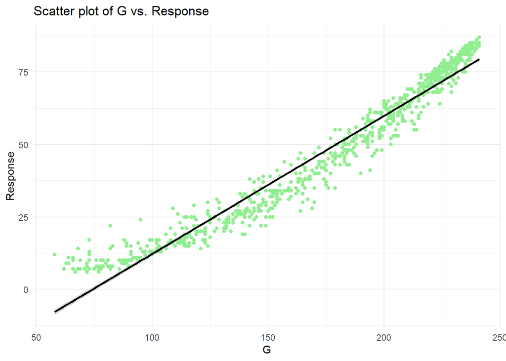

```r
ggplot(df_train, aes(x = G, y = response)) +
  geom_point(color="lightgreen") +
  geom_smooth(method = "lm",formula = y ~ x, col = "black") +
  labs(title = "Scatter plot of G vs. Response", x = "G", y = "Response") +
  theme_minimal()
```

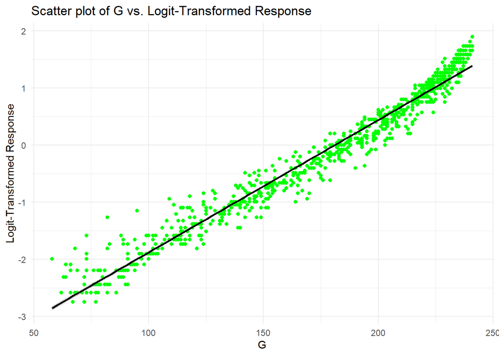

```r
ggplot(df_train, aes(x = G, y = logit_response)) +
  geom_point(color="green") +
  geom_smooth(method = "lm",formula = y ~ x, col = "black") +
  labs(title = "Scatter plot of G vs. Logit-Transformed Response", x = "G", y = "Logit-Transformed Response") +
  theme_minimal()
```

The scatter plots suggest a clear positive trend between ‘G’ and both ‘Response’ and ‘Logit-Transformed Response’. Points cluster around an ascending line, indicating that as ‘G’ increases, so does the ‘Response’ and its logit transformation. This trend seems to hold regardless of the categorical inputs, as they are not differentiated in the plots.

**Hue vs Response and Logit-Transform**

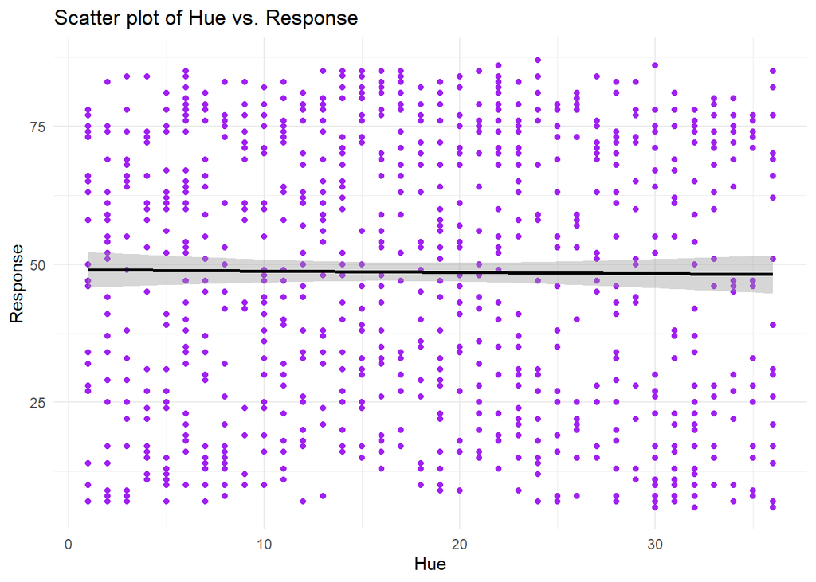

```r
ggplot(df_train, aes(x = Hue, y = response)) +
  geom_point(color="purple") +
  geom_smooth(method = "lm",formula = y ~ x, col = "black") +
  labs(title = "Scatter plot of Hue vs. Response", x = "Hue", y = "Response") +
  theme_minimal()
```

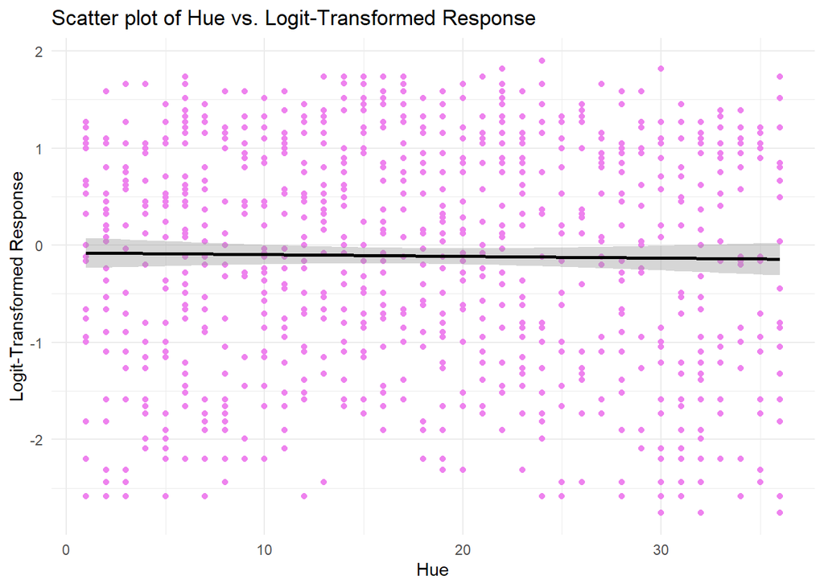

```r
ggplot(df_train, aes(x = Hue, y = logit_response)) +
  geom_point(color="violet") +
  geom_smooth(method = "lm",formula = y ~ x, col = "black") +
  labs(title = "Scatter plot of Hue vs. Logit-Transformed Response", x = "Hue", y = "Logit-Transformed Response") +
  theme_minimal()
```

From the scatter plots, there is no immediately clear linear trend or correlation visible between ‘Hue’ and the ‘Response’ or the ‘Logit-Transformed Response’. The points are widely spread out, indicating high variance and low correlation. While the regression line is included, it appears to be horizontal or nearly so in both cases, which suggests no strong linear relationship. It is not possible to determine from these plots alone whether the trends depend on the categorical inputs; for that, we would need to visualize interactions or conduct a more in-depth statistical analysis that incorporates the categorical variables.